## **Bayesian modeling and prediction for movies**

Author: Yash Verma  
Date: 13.06.2019

### **Data collection**

IMDb started in 1990 as a hobby project by an international group of movie and TV fans. IMDb is now the world’s most popular and authoritative source for movie, TV and celebrity content.

The information in IMDb comes from various sources. While they actively gather information from and verify items with studios and filmmakers, the bulk of our information is submitted by people in the industry and visitors like you. In addition to using as many sources as we can, the data goes through consistency checks to ensure it’s as accurate and reliable as possible. However, there’s absolutely no substitute for an international team of entertainment fans with an encyclopedic knowledge of trivia and a large assortment of reference works (and we include in this group many of our loyal contributors). The sources of information include, but are not limited to, on-screen credits, press kits, official bios, autobiographies, and interviews.

#### **Dataset and further Information**

Dataset and further information used to perform the given analysis were obtained from the following sources:

- Dataset: Movies Data
- Codebook: Movies Codebook
- Rotten Tomatoes: [Rotten Tomatoes](https://www.rottentomatoes.com/)
- IMDB: [IMDB](http://www.imdb.com/)

#### **Generalizability**

The present data were derived from an observational study. The data set is comprised of 651 randomly sampled movies produced and released from 1970 to 2014. According to IMDb, there have 9,962 movies been release from 1972 to 2016 so that the 10% condition (9,962*10% = 996) is met. Since the sampling size is large enough and less than 10% of population, it can assume that the random sampling is conducted. Therefore we can conclude that the sample is indeed generalizable to the entire population.

#### **Causality**

The data cannot be used to establish a causal relation between the variables of interest as there was no random assignment to the explanatory and independent variables.

### **Setup**

#### **Load packages**

```r
library('ggplot2')      # library to create plots
library('dplyr')        # data manipulation
library('tidyr')
library('statsr')       # staistics functions
library('BAS')          # Bayesian statistics functions
library('GGally')       # library to create plots
library('knitr')        # required to apply knitr options
library('grid')         # arrange plots
library('gridExtra')    # arrange plots
library('MASS')         # AIC functions
source('Utilities.R')   # support functions used in the analysis - See Appendix

# apply general knitr options
knitr::opts_chunk$set(comment=NA, fig.align='center')
```

#### **Load data**

Initial load of the dataset.

```r
load("Data/movies.Rdata")
data <- movies
```

## Part 1: Data

The movies data from IMDB was used for the analysis at hand. Some of variables are in the original dataset provided, and others are new variables. This will need be to construct in the data manipulation section.

Perform an initial check of the loaded dataset.

```r
# evaluate the size of the dataset
dim(data)
```

```
[1] 651  32
```

The output for the summary- and str() - function has been hidden since the output would be quiet exhaustive (verbose) by having 32 variables.

```r
# verify types and summary of each variable
str(data)
summary(data)
```

### **Part 2: Data manipulation**

In the original dataset , not all of the required features have been provided, so we will perform some feature engineering to create the required features. For the analysis new features as oscar_season, summer_season, mpaa_rating_R, drama and feature_film. All of them can be derived from existing variables in the dataset.

```r
# ============================================================================================================
# Feature Engineering
# ============================================================================================================

# reasign yes or no to feature oscar_season, where release month is either  "10", "11", "12"
data <- data %>% mutate(oscar_season = as.factor(ifelse(thtr_rel_month %in% c('10', '11', '12'), 'yes', 'no')))

# reasign yes or no to feature summer_season, where release month is either  "6", "7", "8"
data <- data %>% mutate(summer_season = as.factor(ifelse(thtr_rel_month %in% c('6', '7', '8'), 'yes', 'no')))

# reasign yes or no to feature mpaa_rating_R, where mpaa_rating is "R"
data <- data %>% mutate(mpaa_rating_R = as.factor(ifelse(mpaa_rating == 'R', 'yes', 'no')))

# reasign yes or no to feature drama, where genre is "drama"
data <- data %>% mutate(drama = as.factor(ifelse(genre ==  'Drama', 'yes', 'no')))

# reasign yes or no to feature feature_film, where title_type is "Feature Film"
data <- data %>% mutate(feature_film = as.factor(ifelse(title_type ==  'Feature Film', 'yes', 'no')))
```

### **Part 3: Exploratory data analysis**

The response variable of interest is **audience score**. To analyse the newly created features, we will create a subset of the full dataset, which only contains the required data. Then will remove the NA’s from the dataset and check the audience_score data via a density function (incl. histogram) of the audience_score. I also applied the mean, median and the mode values to the figure. The dmode function is part of the utilities script and is available in the appendix.

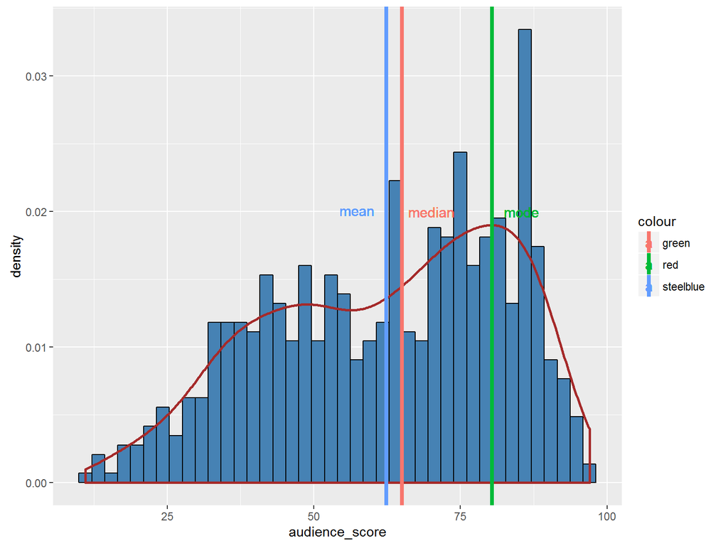

```r
features <- c('audience_score', 'oscar_season', 'summer_season', 'mpaa_rating_R', 'drama', 'feature_film' )

  # Create a new dataset to explicitely show dataset containing NA's
  data.analysis <- data[, features]

  # remove NA's
  data.analysis <- data.analysis[complete.cases(data.analysis), ]

  # calculate the mode of the distribution
  mode <- dmode(data.analysis$audience_score)

  ggplot(data = data.analysis, aes(x = audience_score, y = ..density..)) +
  geom_histogram(bins = 40, fill = 'steelblue', colour = 'black') + #bdbdbd
  geom_density(size = 1, colour = 'brown') + #cccccc
  geom_vline(data = data, mapping = aes( xintercept = mean(data$audience_score),
             colour = 'steelblue', show_guide = F ), size = 1.5) +
  geom_vline(data = data,mapping = aes( xintercept = median(data$audience_score),
             colour = 'green', show_guide = F), size = 1.5) +
  geom_vline(data = data, mapping = aes( xintercept = mode, colour = 'red', show_guide = F),
             size = 1.5) +
  geom_text(data = data, aes( x = (mean(data$audience_score) - 5), y = .020, label = 'mean',
            colour = 'steelblue'), size = 4, parse = T) +
  geom_text(data = data,aes( x = (median(data$audience_score) + 5),y = .020,  label = 'median',
            colour = 'green'), size = 4, parse = T) +
  geom_text(data = data, aes( x = (mode + 5), y = .020, label = 'mode', colour = 'red'),
            size = 4, parse = T)
```

```r
  mean(data.analysis$audience_score)
```

```
[1] 62.36252
```

```r
  median(data.analysis$audience_score)
```

```
[1] 65
```

```r
  mode
```

```
[1] 80.42094
```

```r
  summary(data.analysis$audience_score)
```

```
   Min. 1st Qu.  Median    Mean 3rd Qu.    Max.
  11.00   46.00   65.00   62.36   80.00   97.00
```

```r
  IQR(data.analysis$audience_score)
```

```
[1] 34
```

The audience_score shows a slight left skewed structure. The IQR of the audience_score is 34 (1st Qu - 46 and 3rd Qu. 80), while the mean is around 62.4, the median is 65 and the mode is about 80.42.

#### **Analysis of the newly created features**

We’ll have a look at the newly created features **oscar_season, summer_season, mpaa_rating_R, drama and feature_film**. We create a boxplot for each feature, comparing them with the audience_score. We will also analyse the variability of the new features by comparing them to each other.

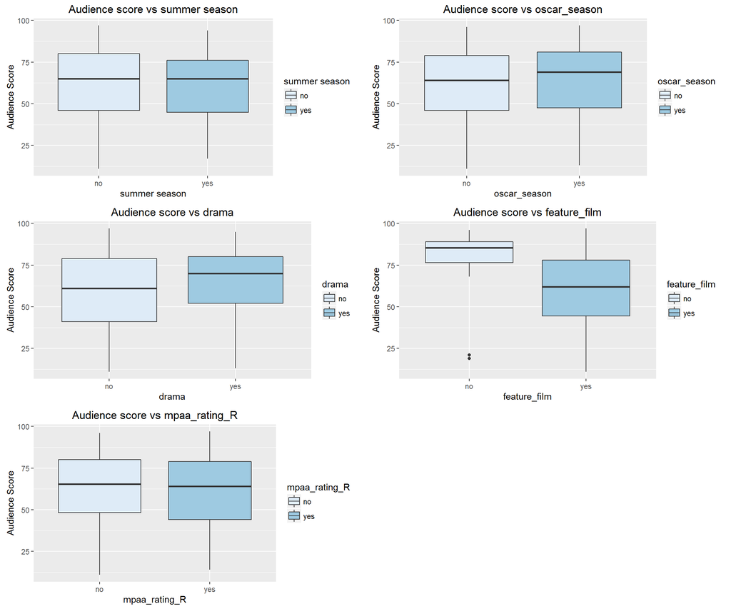

```r
data.grouped <- gather(data.analysis, 'features', 'flag', 2:6)

p1 <- ggplot(data = data.analysis, aes(x = summer_season, y = audience_score, fill = summer_season)) +
      geom_boxplot() + ggtitle('Audience score vs summer season') + xlab('summer season') +
      ylab('Audience Score') + scale_fill_brewer(name = "summer season")

p2 <- ggplot(data = data.analysis, aes(x = oscar_season, y = audience_score, fill = oscar_season)) +
      geom_boxplot() + ggtitle('Audience score vs oscar_season') + xlab('oscar_season') +
      ylab('Audience Score') + scale_fill_brewer(name = "oscar_season")

p3 <- ggplot(data = data.analysis, aes(x = drama, y = audience_score, fill = drama)) + geom_boxplot() +
      ggtitle('Audience score vs drama') + xlab('drama') + ylab('Audience Score') +
      scale_fill_brewer(name = "drama")

p4 <- ggplot(data = data.analysis, aes(x = feature_film, y = audience_score, fill = feature_film)) +
      geom_boxplot() + ggtitle('Audience score vs feature_film') + xlab('feature_film') +
      ylab('Audience Score') + scale_fill_brewer(name = "feature_film")

p5 <- ggplot(data = data.analysis, aes(x = mpaa_rating_R, y = audience_score, fill = mpaa_rating_R)) +
      geom_boxplot() + ggtitle('Audience score vs mpaa_rating_R') + xlab('mpaa_rating_R') +
      ylab('Audience Score') + scale_fill_brewer(name = "mpaa_rating_R")

# arrange the previously created plots
grid.arrange(p1, p2, p3, p4, p5, ncol = 2)
```

To compare the variability of the different features we aggregate all the above shown boxplots in one graph. We also prep a summary of all the newly created features to closer compare them.

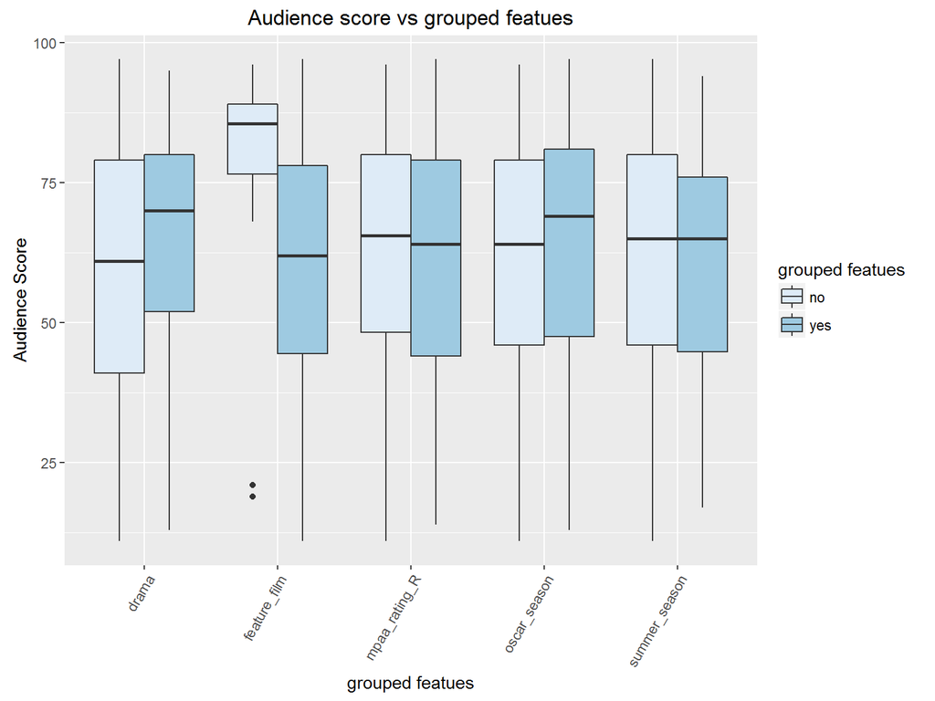

```r
      ggplot(data = data.grouped, aes(x = features, y = audience_score, fill = flag)) + geom_boxplot() +
      ggtitle('Audience score vs grouped featues') + xlab('grouped featues') + ylab('Audience Score') +
      theme(axis.text.x = element_text(angle = 60, hjust = 1)) +
      scale_fill_brewer(name = "grouped featues")
```

```r
data.grouped %>%
 group_by(features, flag) %>%
 summarise(mean = mean(audience_score), median = median(audience_score), min = min(audience_score),
           max = max(audience_score), IQR = IQR(audience_score))
```

```
Source: local data frame [10 x 7]
Groups: features [?]

        features  flag     mean median   min   max   IQR
           <chr> <chr>    <dbl>  <dbl> <dbl> <dbl> <dbl>
1          drama    no 59.73121   61.0    11    97 38.00
2          drama   yes 65.34754   70.0    13    95 28.00
3   feature_film    no 81.05000   85.5    19    96 12.50
4   feature_film   yes 60.46531   62.0    11    97 33.50
5  mpaa_rating_R    no 62.68944   65.5    11    96 31.75
6  mpaa_rating_R   yes 62.04255   64.0    14    97 35.00
7   oscar_season    no 61.81304   64.0    11    96 33.00
8   oscar_season   yes 63.68586   69.0    13    97 33.50
9  summer_season    no 62.60370   65.0    11    97 34.00
10 summer_season   yes 61.64634   65.0    17    94 31.25
```

The new features do not show much variability in the different features, which **leads to the conclusion that none of the above features are valuable towards the prediction of the audience score. The only feature which might be relevant, could be the ‘feature_film’ feature. There seems to be a clear differentiation.** But we shouldn’t jump into conclusions right away, therefore we will continue analysing the data.

Finally we will have a look at the other features used in the dataset. I left out the features as runtime, imdb_rating, imdb_num_votes, Above a selection of Density plots have been visualized. The plots show different features compared to the audience score.

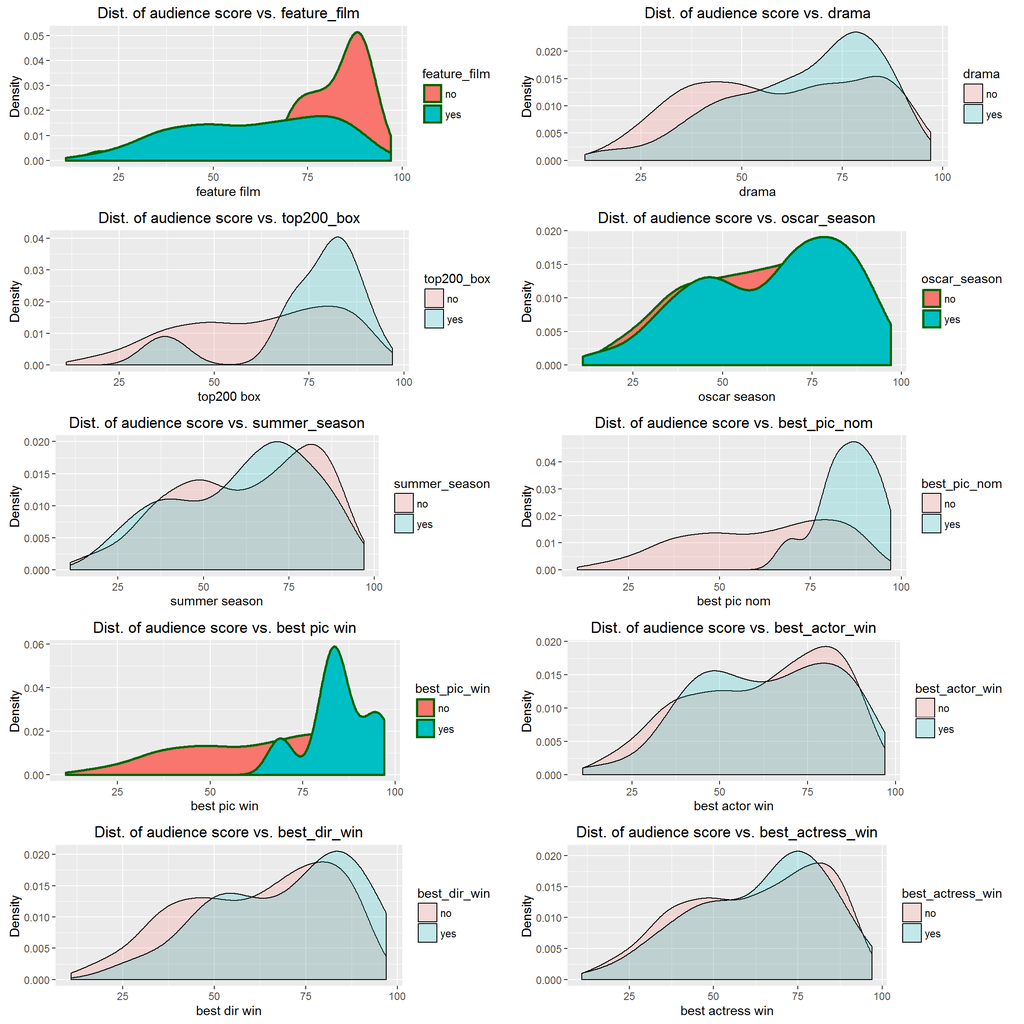

```r
features <- c( 'audience_score', 'feature_film', 'drama', 'runtime', 'mpaa_rating_R', 'thtr_rel_year',
               'oscar_season', 'summer_season', 'imdb_rating', 'imdb_num_votes', 'critics_score',
               'best_pic_nom', 'best_pic_win', 'best_actor_win', 'best_actress_win', 'best_dir_win',
               'top200_box')

    # Create a new dataset to explicitely show dataset containing NA's
    data.model <- data[, features]

    # remove NA's
    data.model<- data.model[complete.cases(data.model), ]

    p1 <- ggplot(data.model, aes(audience_score, fill = feature_film))
    p1 <- p1 + geom_density(size=1, colour="darkgreen") + labs(title = "Dist. of audience score vs. feature_film") +
               labs(x = "feature film", y = "Density")

    p2 <- ggplot(data.model, aes(audience_score, fill = drama))
    p2 <- p2 + geom_density (alpha = 0.2) + labs(title = "Dist. of audience score vs. drama") +
               labs(x = "drama", y = "Density")

    p3 <- ggplot(data.model, aes(audience_score, fill = top200_box))
    p3 <- p3 + geom_density (alpha = 0.2) + labs(title = "Dist. of audience score vs. top200_box") +
               labs(x = "top200 box", y = "Density")

    p4 <- ggplot(data.model, aes(audience_score, fill = oscar_season))
    p4 <- p4 + geom_density(size=1, colour="darkgreen") + labs(title = "Dist. of audience score vs. oscar_season") +
               labs(x = "oscar season", y = "Density")

    p5 <- ggplot(data.model, aes(audience_score, fill = summer_season))
    p5 <- p5 + geom_density (alpha = 0.2) + labs(title = "Dist. of audience score vs. summer_season") +
               labs(x = "summer season", y = "Density")

    p6 <- ggplot(data.model, aes(audience_score, fill = best_pic_nom))
    p6  <- p6 + geom_density (alpha = 0.2) + labs(title = "Dist. of audience score vs. best_pic_nom") +
                labs(x = "best pic nom", y = "Density")

    p7 <- ggplot(data.model, aes(audience_score, fill = best_pic_win))
    p7 <- p7 + geom_density(size=1, colour="darkgreen") + labs(title = "Dist. of audience score vs. best pic win") +
               labs(x = "best pic win", y = "Density")

    p8 <- ggplot(data.model, aes(audience_score, fill = best_actor_win))
    p8 <- p8 + geom_density (alpha = 0.2) + labs(title = "Dist. of audience score vs. best_actor_win") +
               labs(x = "best actor win", y = "Density")

    p9 <- ggplot(data.model, aes(audience_score, fill = best_dir_win))
    p9 <- p9 + geom_density (alpha = 0.2) + labs(title = "Dist. of audience score vs. best_dir_win") +
               labs(x = "best dir win", y = "Density")

    p10 <- ggplot(data.model, aes(audience_score, fill = best_actress_win))
    p10 <- p10 + geom_density (alpha = 0.2) + labs(title = "Dist. of audience score vs. best_actress_win") +
                 labs(x = "best actress win", y = "Density")

    grid.arrange(p1, p2, p3, p4, p5, p6, p7, p8, p9, p10, ncol = 2)
```

#### **Hypothesis Test**

As with the frequentist approach we use these data to perform basic inference on μ the audience_score of all movies in the dataset. To do this we will use the bayes_inference function, which will allow us to construct credible intervals perform a hypothesis test and calculate Bayes factors for a variety of different circumstances. The main goal is to investigate if the newly created features influence the audience_score. Remember we assumed that the new fetures will not influence the audience_score very much.

We will conduct a Bayesian hypothesis test by calculating a Bayes factor for each feature. The following hypothesis is meant to be generic and needs to be adjusted for each individual feature (feature_film, drama, mpaa_rating_R, oscar_season and summer_season). We assigned a uniform prior and use a ‘two sided’ direction for each analysis. I’ll just print on of the summaries to indicate the information which is contained. All others will be suppressed to save some space. Enable the params - show_res and show_summ by setting the value to TRUE.

$$H_1: \mu = (value)$$

$$H_2: \mu \ne (value)$$

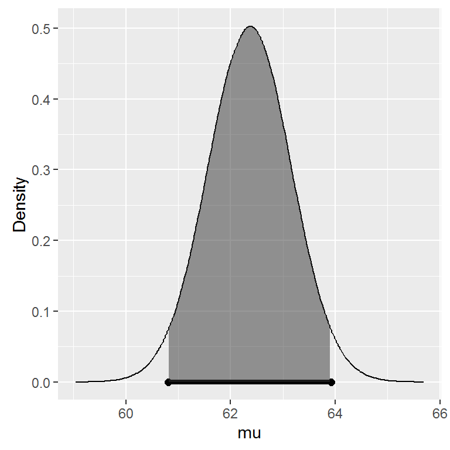

```r
bayes_inference(y = audience_score, data = data.analysis, cred_level = 0.95, statistic = "mean", type = "ci", null = 0, show_res = FALSE, show_summ = FALSE)
```

```r
bayes_inference(x = feature_film, y = audience_score, data = data.analysis, cred_level = 0.95, hypothesis_prior = c(0.5, 0.5), statistic = "mean", type = "ht", null = 0, alternative = 'twosided', show_res = TRUE, show_summ = TRUE)
```

```
Response variable: numerical, Explanatory variable: categorical (2 levels)
n_no = 60, y_bar_no = 81.05, s_no = 13.5764
n_yes = 591, y_bar_yes = 60.4653, s_yes = 19.824
(Assuming intrinsic prior on parameters)
Hypotheses:
H1: mu_no  = mu_yes
H2: mu_no != mu_yes

Priors:
P(H1) = 0.5
P(H2) = 0.5

Results:
BF[H2:H1] = 4.221452e+13
P(H1|data) = 0
P(H2|data) = 1
```

[figure not shown]

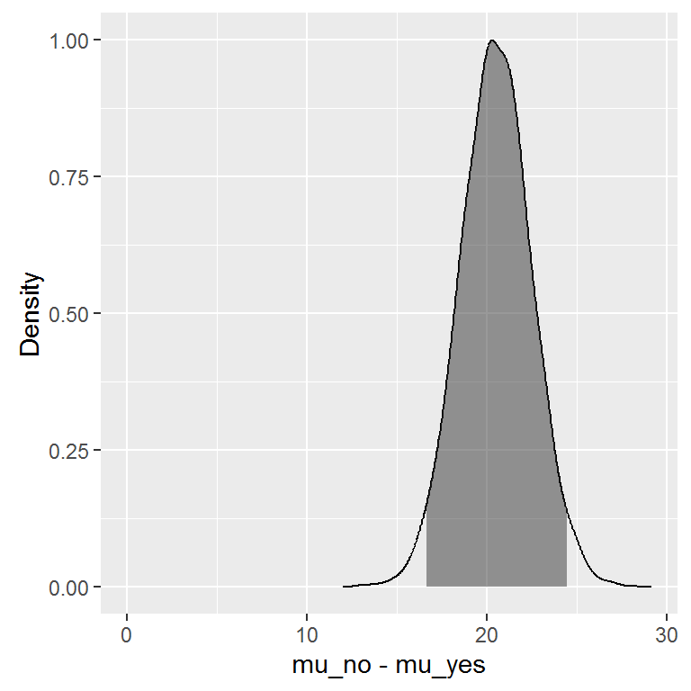

```r
bayes_inference(x = feature_film, y = audience_score, data = data.analysis, cred_level = 0.95, hypothesis_prior = c(0.5, 0.5), statistic = "mean", type = "ht", null = 0, alternative = 'twosided', show_res = FALSE, show_summ = FALSE )
```

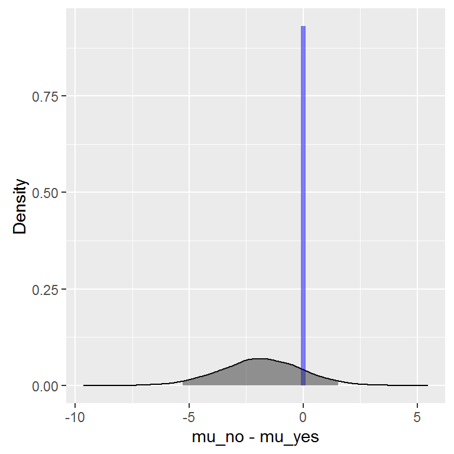

```r
bayes_inference(x = oscar_season, y = audience_score, data = data.analysis, cred_level = 0.95, hypothesis_prior = c(0.5, 0.5), statistic = "mean", type = "ht", null = 0, alternative = 'twosided', show_res = FALSE, show_summ = FALSE)
```

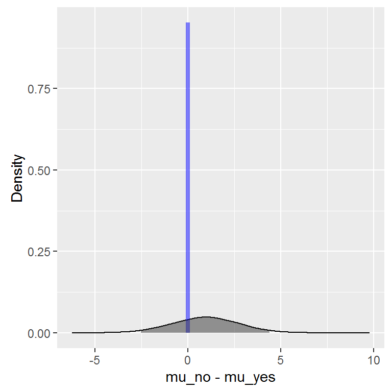

```r
bayes_inference(x = summer_season, y = audience_score, data = data.analysis, cred_level = 0.95, hypothesis_prior = c(0.5, 0.5), statistic = "mean", type = "ht", null = 0, alternative = 'twosided', show_res = FALSE, show_summ = FALSE)
```

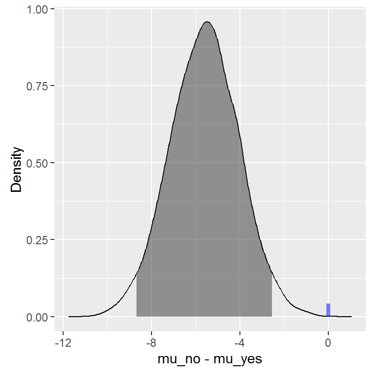

```r
bayes_inference(x = drama, y = audience_score, data = data.analysis, cred_level = 0.95, hypothesis_prior = c(0.5, 0.5), statistic = "mean", type = "ht", null = 0, alternative = 'twosided', show_res = FALSE, show_summ = FALSE)
```

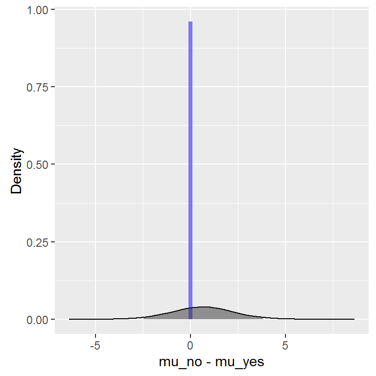

```r
bayes_inference(x = mpaa_rating_R, y = audience_score, data = data.analysis, cred_level = 0.95, hypothesis_prior = c(0.5, 0.5), statistic = "mean", type = "ht", null = 0, alternative = 'twosided', show_res = FALSE, show_summ = FALSE)
```

**Bayes Factors**

| feature | BF[H1:H2] | BF[H2:H1] | Evidence against |
| --- | --- | --- | --- |
| feature_film |  | 4.22e+13 | H1 (Very Strong) |
| oscar_season | 13.3993 |  | H2 (Positive) |
| summer_season | 19.8084 |  | H2 (Positive) |
| drama |  | 22.6567 | H1 (Positive) |
| mpaa_rating_R | 23.9679 |  | H2 (Positive) |

### **Part 4: Modelling**

The best model is not always the most complicated. Sometimes including variables that are not evidently important, can actually reduce the accuracy of predictions. In practice, the model that includes all available explanatory variables is often referred to as the full model. The full model may not be the best model, and if it isn’t, we want to identify a smaller model that is preferable.

**Full model:**  
**audience_score ~ feature_film + drama + runtime + mpaa_rating_R + thtr_rel_year + oscar_season + summer_season + imdb_rating + imdb_num_votes + critics_score + best_pic_nom + best_pic_win + best_actor_win + best_actress_win + best_dir_win + top200_box**

We show the model selection based on two different priors (Zellner and BIC), but we will also compare the model selection based on the following priors “g-prior”, “AIC”, “hyper-g-n”, “EB-local”. The last part will indicate the Akaike information criterion (AIC), which uses a backward feature elimination method and the model which is proposed by this approach.

```r
features <- c( 'audience_score', 'feature_film', 'drama', 'runtime', 'mpaa_rating_R', 'thtr_rel_year',
               'oscar_season', 'summer_season', 'imdb_rating', 'imdb_num_votes', 'critics_score',
               'best_pic_nom', 'best_pic_win', 'best_actor_win', 'best_actress_win', 'best_dir_win',
               'top200_box')

    # Create a new dataset to explicitely show dataset containing NA's
    data.model <- data[, features]

    # remove NA's
    data.model<- data.model[complete.cases(data.model), ]

    # str(data.model)

    formula <- getFormula(data.model, 'audience_score')
```

#### **Bayesian Information Criterion**

```r
    audience.BIC = bas.lm(
      formula = formula,
      prior = "BIC",
      modelprior = uniform(),
      data = data.model
    )
```

The object provides the marginal posterior inclusion probabilities. The marginal posterior inclusion probability is the probability that the predictor variable is included in the model. We can also extract this directly from the object as

```r
    audience.BIC$probne0
```

```
 [1] 1.00000000 0.06475617 0.04308556 0.47067030 0.20009502 0.09050567
 [7] 0.07703667 0.04080086 1.00000000 0.05796731 0.89156709 0.13014756
[13] 0.03982897 0.14531668 0.14134972 0.06679156 0.04771535
```

**Coefficient Summaries**  
The summary outputs have been aggregated for convenience purposes. The section shows the marginal posterior mean, standard deviation and posterior inclusion probabilities obtained by BMA.

```r
audience.BIC.coef = coef(audience.BIC)
interval   <- confint(audience.BIC.coef)
names <- c("post mean", "post sd", colnames(interval))
interval   <- cbind(audience.BIC.coef$postmean, audience.BIC.coef$postsd, interval)
colnames(interval) <- names
interval
```

```
                        post mean      post sd        2.5  %      97.5  %
Intercept            6.234769e+01 3.946167e-01  6.156645e+01 6.310738e+01
feature_filmyes     -1.026910e-01 5.587450e-01 -1.087623e+00 1.803950e-03
dramayes             1.578519e-02 1.931899e-01  0.000000e+00 0.000000e+00
runtime             -2.574711e-02 3.121048e-02 -8.315045e-02 8.582066e-06
mpaa_rating_Ryes    -3.041432e-01 7.038116e-01 -2.118218e+00 0.000000e+00
thtr_rel_year       -4.518100e-03 1.815856e-02 -5.126281e-02 0.000000e+00
oscar_seasonyes     -8.402533e-02 3.848415e-01 -9.433783e-01 1.497462e-02
summer_seasonyes     1.399590e-02 1.990719e-01  0.000000e+00 0.000000e+00
imdb_rating          1.497376e+01 7.284561e-01  1.362570e+01 1.650921e+01
imdb_num_votes       2.101237e-07 1.318417e-06 -8.009491e-08 1.881780e-06
critics_score        6.332453e-02 3.013544e-02  0.000000e+00 1.054379e-01
best_pic_nomyes      5.009061e-01 1.558141e+00  0.000000e+00 4.979318e+00
best_pic_winyes     -8.236391e-03 8.471404e-01  0.000000e+00 0.000000e+00
best_actor_winyes   -2.903941e-01 8.358697e-01 -2.556473e+00 0.000000e+00
best_actress_winyes -3.090744e-01 9.060905e-01 -2.703026e+00 0.000000e+00
best_dir_winyes     -1.190122e-01 6.214955e-01 -1.310042e+00 0.000000e+00
top200_boxyes        8.704627e-02 7.065880e-01  0.000000e+00 0.000000e+00
                             beta
Intercept            6.234769e+01
feature_filmyes     -1.026910e-01
dramayes             1.578519e-02
runtime             -2.574711e-02
mpaa_rating_Ryes    -3.041432e-01
thtr_rel_year       -4.518100e-03
oscar_seasonyes     -8.402533e-02
summer_seasonyes     1.399590e-02
imdb_rating          1.497376e+01
imdb_num_votes       2.101237e-07
critics_score        6.332453e-02
best_pic_nomyes      5.009061e-01
best_pic_winyes     -8.236391e-03
best_actor_winyes   -2.903941e-01
best_actress_winyes -3.090744e-01
best_dir_winyes     -1.190122e-01
top200_boxyes        8.704627e-02
```

The summary of the given model indicates the top 5 models. The model containing the intercept, runtime, mdb_rating and critics_score, show the best performance, but as one can see, the top 2 models contain only about 27 percent of the posterior mass over all models.

```r
summary(audience.BIC)
```

```
     Intercept feature_filmyes dramayes runtime mpaa_rating_Ryes
[1,]         1               0        0       1                0
[2,]         1               0        0       0                0
[3,]         1               0        0       0                0
[4,]         1               0        0       0                1
[5,]         1               0        0       1                1
     thtr_rel_year oscar_seasonyes summer_seasonyes imdb_rating
[1,]             0               0                0           1
[2,]             0               0                0           1
[3,]             0               0                0           1
[4,]             0               0                0           1
[5,]             0               0                0           1
     imdb_num_votes critics_score best_pic_nomyes best_pic_winyes
[1,]              0             1               0               0
[2,]              0             1               0               0
[3,]              0             1               0               0
[4,]              0             1               0               0
[5,]              0             1               0               0
     best_actor_winyes best_actress_winyes best_dir_winyes top200_boxyes
[1,]                 0                   0               0             0
[2,]                 0                   0               0             0
[3,]                 1                   0               0             0
[4,]                 0                   0               0             0
[5,]                 0                   0               0             0
            BF PostProbs     R2 dim   logmarg
[1,] 1.0000000    0.1353 0.7549   4 -3615.279
[2,] 0.9968489    0.1348 0.7525   3 -3615.282
[3,] 0.2543185    0.0344 0.7539   4 -3616.648
[4,] 0.2521327    0.0341 0.7539   4 -3616.657
[5,] 0.2391994    0.0324 0.7563   5 -3616.710
```

**Model Space**  
To visualize the space of models (by default the top 20 models in terms of their posterior probabilities), we may use the image function. The image below shows the best model on the left hand side (indicated with a 1). It indicates that the best model can be built by using the features - runtime, critics_score and imdb_rating.

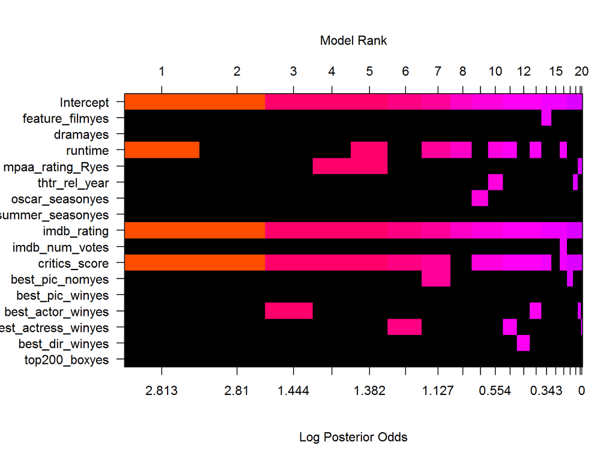

```r
image(audience.BIC, rotate = FALSE)
```

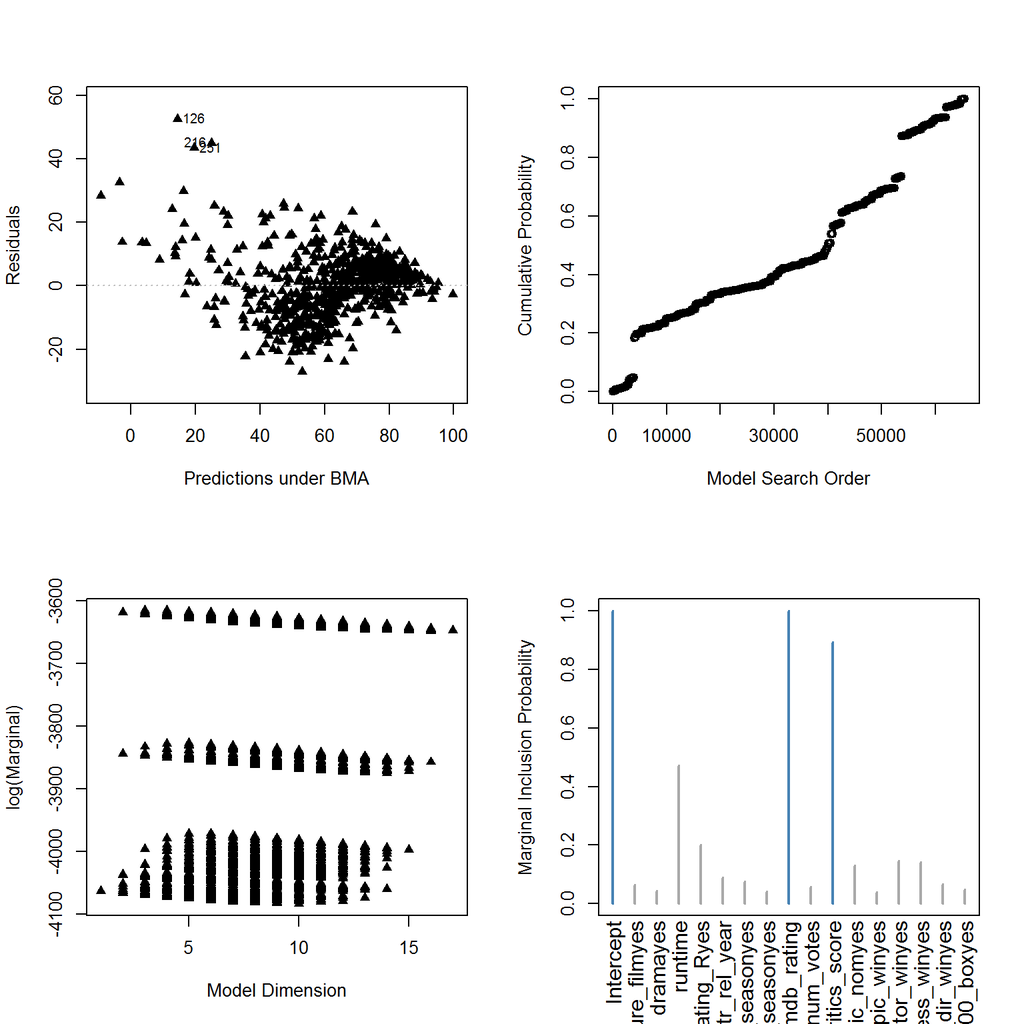

```r
par(mfrow=c(2,2))
plot(audience.BIC, ask = F, add.smooth = F, caption="", col.in = 'steelblue', col.ex  = 'darkgrey', pch=17, lwd=2)
```

#### **Zellner-Siow Cauchy**

We are going to use the Zellner-Siow Cauchy prior with an MCMC method. We define 10^6 iterations for the model.

```r
audience.ZS =  bas.lm(formula = formula,
                   data = data.model,
                   prior="ZS-null",
                   modelprior=uniform(),
                   method = "MCMC",
                   MCMC.iterations = 10^6)
```

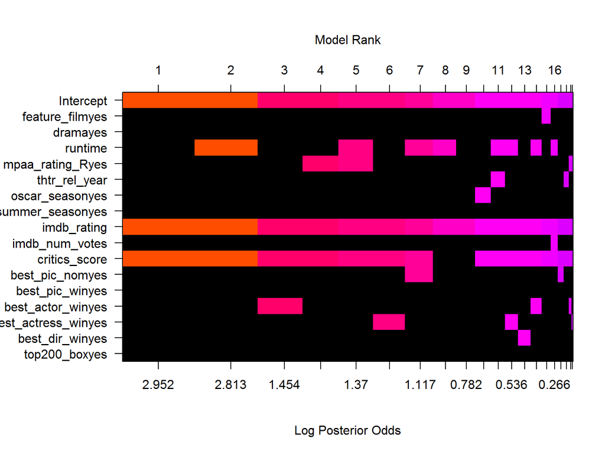

```r
image(audience.ZS, rotate = FALSE)
```

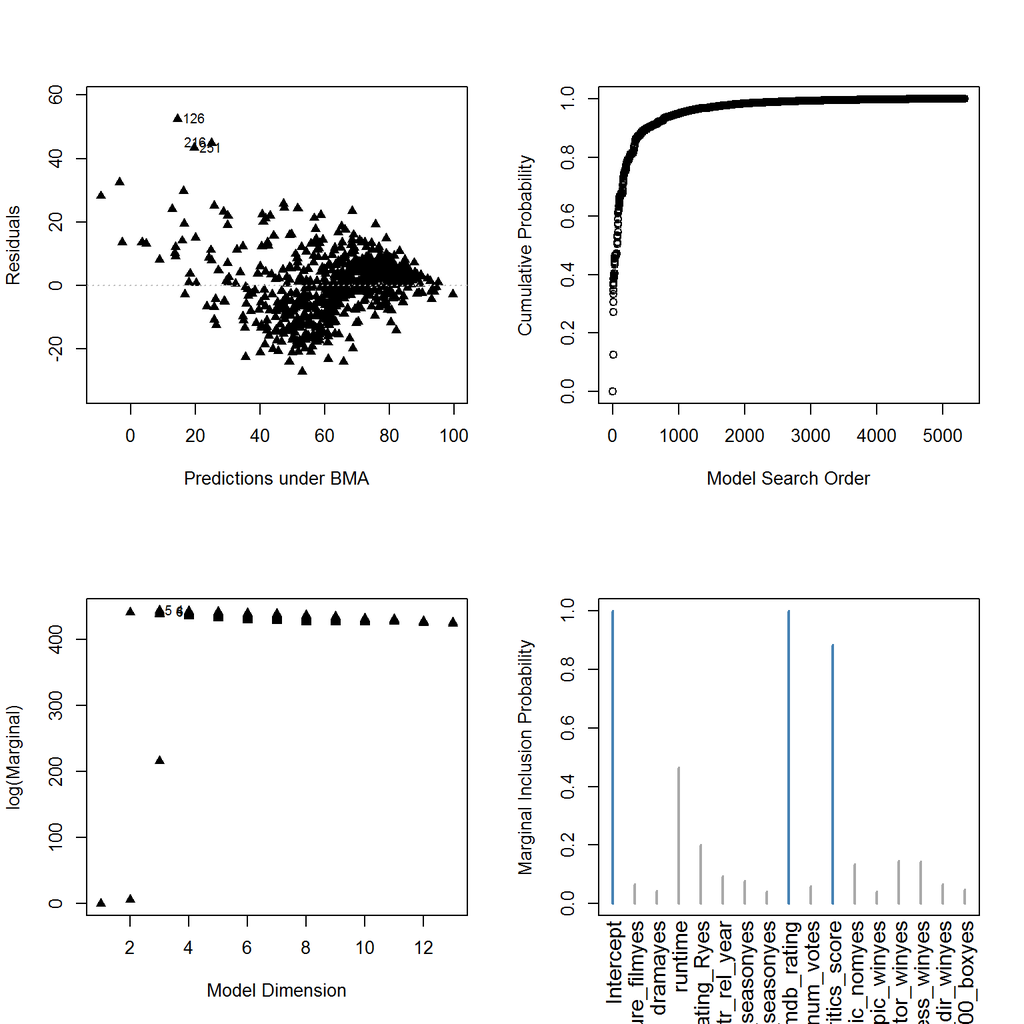

```r
par(mfrow=c(2,2))
plot(audience.ZS, ask=F, add.smooth=F, caption="", col.in = 'steelblue', col.ex  = 'darkgrey', pch=17, lwd=2)
```

As we can see the, based on the different priors (BIC and ZS-null) the models as such differ. With a BIC prior, we have an ideal model which proposes the features ‘runtime’, ‘imdb_rating’ and ‘critics_score’, while on the other hand the ZS-null prior proposes a model with features ‘imdb_rating’ and ‘critics_score’.

#### **AIC Model Selection**

The Akaike information criterion (AIC) is a measure of the relative quality of statistical models for a given set of data. Given a collection of models for the data, AIC estimates the quality of each model, relative to each of the other models. Hence, AIC provides a means for model selection.

The AIC model might not deliver the parsimonious model, but often provides a model, which provides a better prediction. We use the backward elimination to find the best model.

```r
      lm.AIC <- lm(formula, data = data.model)
      aic.model <- stepAIC(lm.AIC, direction = 'backward', trace = FALSE)
      aic.model$anova
```

```
Stepwise Model Path
Analysis of Deviance Table

Initial Model:
audience_score ~ feature_film + drama + runtime + mpaa_rating_R +
    thtr_rel_year + oscar_season + summer_season + imdb_rating +
    imdb_num_votes + critics_score + best_pic_nom + best_pic_win +
    best_actor_win + best_actress_win + best_dir_win + top200_box

Final Model:
audience_score ~ runtime + mpaa_rating_R + thtr_rel_year + imdb_rating +
    critics_score + best_pic_nom + best_actor_win + best_actress_win

              Step Df    Deviance Resid. Df Resid. Dev      AIC
1                                       633   63080.98 3007.881
2  - summer_season  1   0.2583583       634   63081.23 3005.884
3     - top200_box  1  12.1318917       635   63093.37 3004.009
4   - best_dir_win  1  46.6853202       636   63140.05 3002.490
5   - best_pic_win  1  85.5472230       637   63225.60 3001.370
6   - oscar_season  1 106.3793211       638   63331.98 3000.463
7   - feature_film  1 155.7300727       639   63487.71 3000.059
8          - drama  1 121.3556022       640   63609.06 2999.300
9 - imdb_num_votes  1 147.8290884       641   63756.89 2998.809
```

As one can see, the conventional AIC proposes the following model, which uses several additional features for prediction:  
audience_score ~ runtime + mpaa_rating_R + thtr_rel_year + imdb_rating + critics_score + best_pic_nom + best_actor_win + best_actress_win

#### **Analysis with different priors**

To indicate which parameters would be favoured output would be quiet exhaustive. So we only used the reduced feature set proposed by Zellner-Siow and BIC.

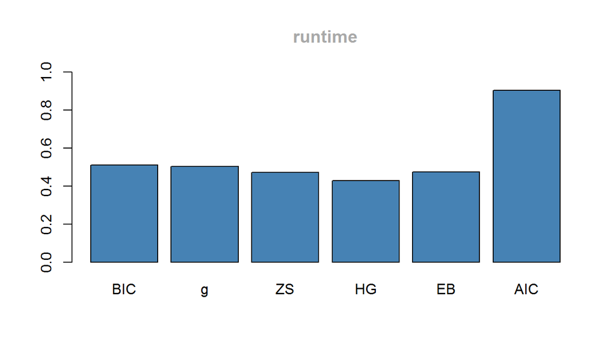

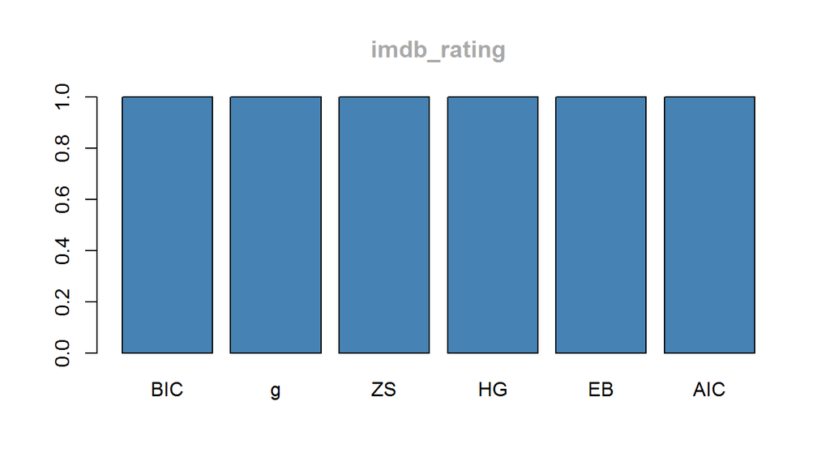

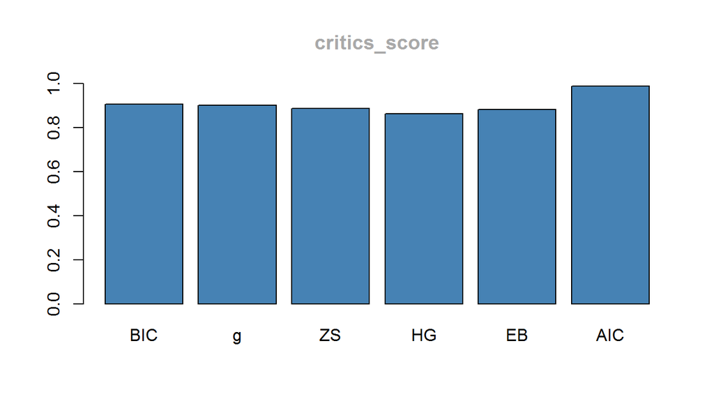

```r
    features <-
      c( 'audience_score', 'runtime', 'imdb_rating', 'critics_score')

    # Create a new dataset to explicitely show dataset containing NA's
    data.final <- data[, features]

    # remove NA's
    data.final<- data.final[complete.cases(data.final), ]
    formula <- getFormula(data.final, 'audience_score')

      n = nrow(data.final)
      movie.g   = bas.lm(formula, data = data.final, prior = "g-prior",   a=n, modelprior = uniform())
      movie.ZS  = bas.lm(formula, data = data.final, prior = "ZS-null",   a=n, modelprior = uniform())
      movie.BIC = bas.lm(formula, data = data.final, prior = "BIC",       a=n, modelprior = uniform())
      movie.AIC = bas.lm(formula, data = data.final, prior = "AIC",       a=n, modelprior = uniform())
      movie.HG  = bas.lm(formula, data = data.final, prior = "hyper-g-n", a=3, modelprior = uniform())
      movie.EB  = bas.lm(formula, data = data.final, prior = "EB-local",  a=n, modelprior = uniform())

      probne0 = cbind(movie.BIC$probne0, movie.g$probne0, movie.ZS$probne0, movie.HG$probne0, movie.EB$probne0,
                      movie.AIC$probne0)
      colnames(probne0) = c("BIC","g", "ZS", "HG", "EB", "AIC")
      rownames(probne0) = c(movie.BIC$namesx)

      for (i in 2:4) {
        barplot(height = probne0[i,], ylim = c(0,1), main = movie.g$namesx[i], col.main = 'darkgrey',
                col = 'steelblue')
      }
```

#### **Final Model**

```r
    features <- c( 'audience_score', 'imdb_rating', 'critics_score' )

    # Create a new dataset to explicitely show dataset containing NA's
    data.final <- data[, features]

    # remove NA's
    data.final<- data.final[complete.cases(data.final), ]
    formula <- getFormula(data.final, 'audience_score')

    audience.ZS =  bas.lm(audience_score ~ .,
                          data = data.final,
                          prior = "ZS-null",
                          modelprior = uniform(),
                          method = "MCMC",
                          MCMC.iterations = 10^6)
```

#### **Inference with model selection**

In addition to using BMA, we can use the posterior means under model selection. This corresponds to a decision rule that combines estimation and selection.

**Bayesian model averaging**

```r
model <- audience.ZS
BMA  = predict(model, estimator="BMA")
```

```r
HPM = predict(model, estimator="HPM")

model.ZS = coef(model)
model.ZS$conditionalmeans[HPM$best,]
```

```
    Intercept   imdb_rating critics_score
  62.36251920   14.64077841    0.07309197
```

```r
model.ZS$conditionalsd[HPM$best,]
```

```
    Intercept   imdb_rating critics_score
   0.39501689    0.56557991    0.02160024
```

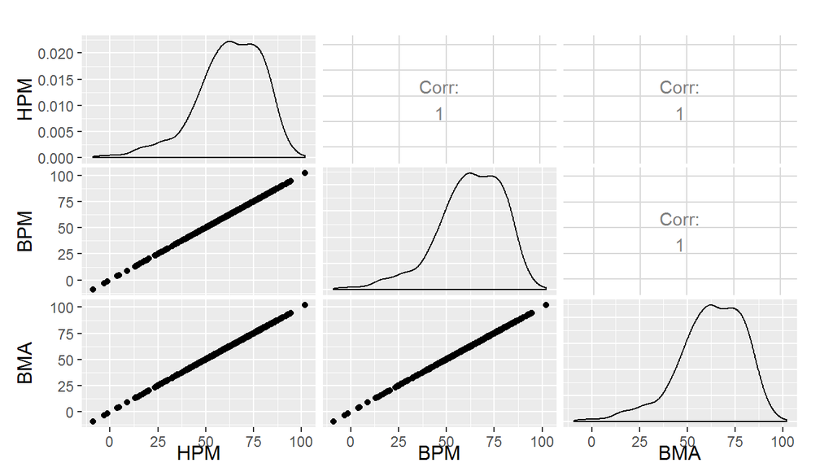

```r
BMA <- predict(model, estimator="BMA")  # Bayesian model averaging, using optionally only the 'top' models
HPM <- predict(model, estimator="HPM")  # The highest probability model
BPM <- predict(model, estimator="BPM")  # The model that is closest to BMA predictions under squared error loss.
# MPM <- predict(model, estimator="MPM")  # The median probability model of Barbieri and Berger

library(GGally)
ggpairs(data.frame(HPM = as.vector(HPM$fit),  #this used predict so we need to extract fitted values
                   BPM = as.vector(BPM$fit),  # this used fitted
                   BMA = as.vector(BMA$fit))) # this used predict
```

```r
BPM = predict(audience.ZS, estimator="BPM", se.fit=TRUE)
audience.conf.fit = confint(BPM, parm="mean")
audience.conf.pred = confint(BPM, parm="pred")
# cbind(audience.conf.fit, audience.conf.pred)
# plot(audience.conf.fit)
```

### **Part 5: Prediction**

```r
    features <- c( 'audience_score', 'imdb_rating', 'critics_score' )

    # Create a new dataset to explicitely show dataset containing NA's
    data.final <- data[, features]

    # remove NA's
    data.final<- data.final[complete.cases(data.final), ]

    ds <- splitTrainTestSet(data = data.final, 0.6)
    df.train <- data.frame(ds$train)
    df.test  <- data.frame(ds$test)

    audience.ZS =  bas.lm(audience_score ~ .,
                          data = df.train,
                          prior = "ZS-null",
                          modelprior = uniform(),
                          method = "MCMC",
                          MCMC.iterations = 10^6)

    predict.value <- ds$test[2,]
    pred.A <- predict(audience.ZS, newdata = predict.value, estimator="BMA")

    # Error in percent
    Error_in_percent.A = round(100 - (round(pred.A$Ybma, 2) * 100 / predict.value$audience_score), 2)

    predict.value <- ds$test[34,]
    pred.B <- predict(audience.ZS, newdata = predict.value, estimator="BMA")

    # Error in percent
    Error_in_percent.B = round(100 - (round(pred.B$Ybma, 2) * 100 / predict.value$audience_score), 2)

    # ===============================================================================================
    # Sully
    # ===============================================================================================

    audience.ZS =  bas.lm(audience_score ~ .,
                          data = data.final,
                          prior = "ZS-null",
                          modelprior = uniform(),
                          method = "MCMC",
                          MCMC.iterations = 10^6)

    predict.value <- data.frame( imdb_rating = 7.6, critics_score = 74, audience_score = 80 )
    predict.sully <- predict(audience.ZS, newdata = predict.value, estimator="BMA")
    predict.sully$Ybma
```

```
        [,1]
[1,] 79.8057
```

### **Part 6: Conclusion**

The predictive model presented here is used to predict the audience scores for a movie. Using Bayesian model average many models can be constructed to perform better predictions. The proposed linear model shows a ‘fairly good’ prediction rate, but it should be noted that the model is based on a very small sample. Fact is that imdb_rating has the highest posterior probability, and that basically all of the newly created features were useless to support a better prediction. Creating a model, which has a high predictive power is not so easy to reach. Using Bayes for better prediction is only one part of the game. It might be beneficial to gather more data or try to extend the feature engineering part, which means to creating new meaningful features from existing or gather data for new features. I doubt that a feature as ‘summer_season’ or if a movie has an mpaa_rating - R is supporting the prediction.

I have my personal view on how I would rely on other features to evaluate a audience score (e.g. genre, actors etc.). What I figured as well is, that Lower bound audience_scores show a much higher difference. Therefore we might think about a second or higher order polynomial model. But we still need be carefull to find a decent balance between over-, and underfitting the model.

One last word. Having selected the model based on a bayesian model does not per se mean that the model automatically generalizes better.

[figure not shown]

[interactive chart not shown]